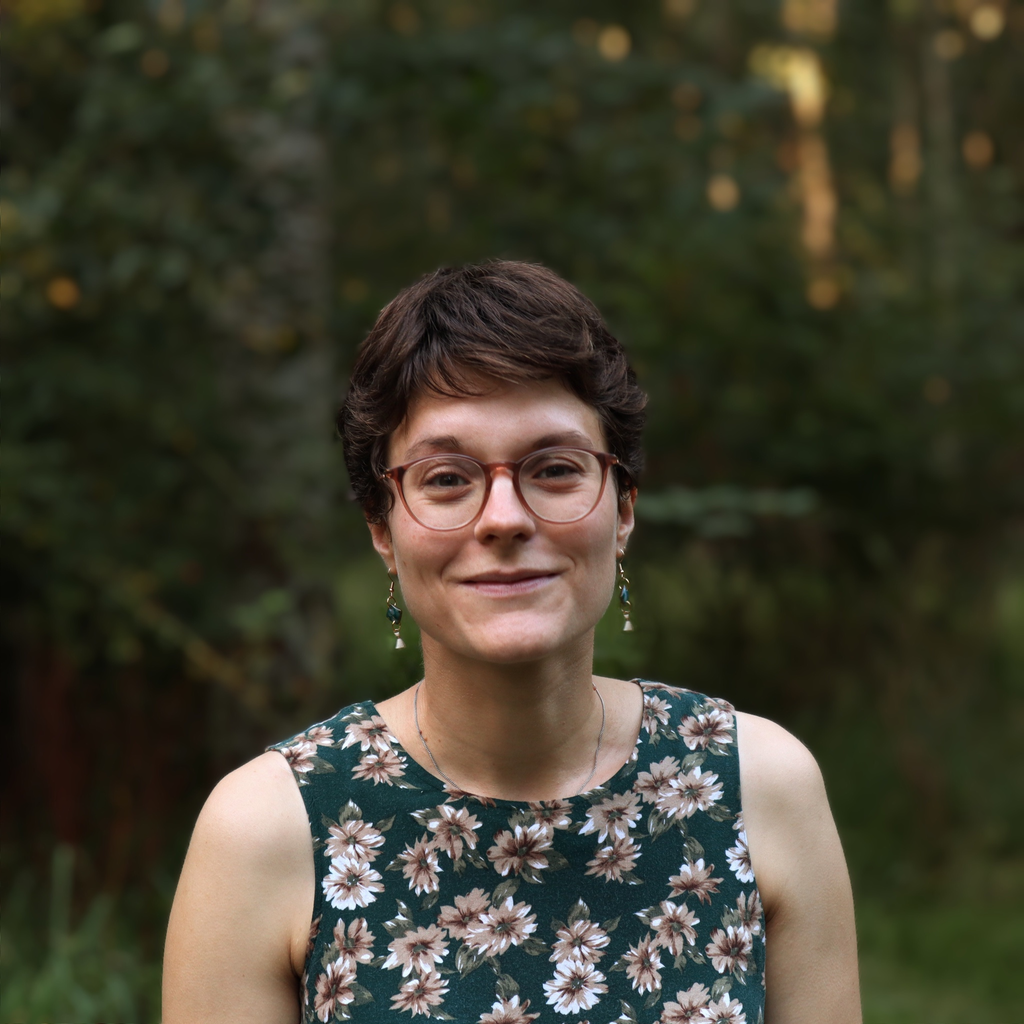

# Camille Magneville, PhD

I study how anthropogenic activities and global changes in general reshape ecosystem functioning, using functional, phylogenetic, and taxonomic diversity as a multidimensional approach of biodiversity. My research so far is organised around (1) **functional diversity and traits** as a tool to understand ecosystem functioning (2) **temporal variability** at short temporal scales such as the diel scale, but also across longer temporal spans to look at how global changes impact biodiversity (3) **human pressures and conservation** by **looking at protected area effectiveness.**

I particularly **enjoy exploring and learning new concepts and methods**, which has for instance recently led me to dive into species interaction networks and their rewiring capacity through collaborations with other early career researchers.

In the future, I aim to link behavioral, functional and macro ecology, to understand how anthropic activities reshape coral reef assemblages and functions.

Please don’t hesitate to reach out, and I will respond to you as soon as possible!